# P&S-2022: Lab assignment 2

Sofiia Folvarochna, Maslenchenko Oleksandra, Andrea Kozlovskyy

## General comments and instructions

- Complete solution will give you $\bf 4$ points (out of 100 total). Submission deadline is **23:59 of 06 November 2022**
- The report must be prepared as an *R notebook*; you must submit to **cms** both the source *R notebook* **and** the generated html file
- At the beginning of the notebook, provide a work-breakdown structure estimating efforts of each team member
- For each task, include
  - problem formulation and discussion (what is a reasonable answer to discuss);
  - the corresponding $\mathbf{R}$ code with comments (usually it is just a couple of lines long);
  - the statistics obtained (like sample mean or anything else you use to complete the task) as well as histograms etc to illustrate your findings;
  - justification of your solution (e.g. refer to the corresponding theorems from probability theory);
  - conclusions (e.g. how reliable your answer is, does it agree with common sense expectations etc)
- The **team id number** referred to in tasks is the **two-digit** ordinal number of your team on the list. Include the line **set.seed(team id number)** at the beginning of your code to make your calculations reproducible. Also observe that the answers **do** depend on this number!
- Take into account that not complying with these instructions may result in point deduction regardless of whether or not your implementation is correct.

### Task 1(Maslenchenko Oleksandra)

#### In this task, we discuss the $[7,4]$ Hamming code and investigate its reliability. That coding system can correct single errors in the transmission of $4$-bit messages and proceeds as follows:

- given a message $\mathbf{m} = (a_1 a_2 a_3 a_4)$, we first encode it to a $7$-bit *codeword* $\mathbf{c} = \mathbf{m}G = (x_1 x_2 x_3 x_4 x_5 x_6 x_7)$, where $G$ is a $4\times 7$ *generator* matrix
- the codeword $\mathbf{c}$ is transmitted, and $\mathbf{r}$ is the received message
- $\mathbf{r}$ is checked for errors by calculating the *syndrome vector* $\mathbf{z} := \mathbf{r} H$, for a $7 \times 3$ *parity-check* matrix $H$
- if a single error has occurred in $\mathbf{r}$, then the binary $\mathbf{z} = (z_1 z_2 z_3)$ identifies the wrong bit no. $z_1 + 2 z_2 + 4z_3$; thus $(0 0 0)$ shows there was no error (or more than one), while $(1 1 0 )$ means the third bit (or more than one) got corrupted
- if the error was identified, then we flip the corresponding bit in $\mathbf{r}$ to get the corrected $\mathbf{r}^* = (r_1 r_2 r_3 r_4 r_5 r_6 r_7)$;
- the decoded message is then $\mathbf{m}^*:= (r_3r_5r_6r_7)$.

#### The **generator** matrix $G$ and the **parity-check** matrix $H$ are given by

$$G :=
\begin{pmatrix}
1 & 1 & 1 & 0 & 0 & 0 & 0 \\
1 & 0 & 0 & 1 & 1 & 0 & 0 \\
0 & 1 & 0 & 1 & 0 & 1 & 0 \\
1 & 1 & 0 & 1 & 0 & 0 & 1 \\
\end{pmatrix},
\qquad
H^\top := \begin{pmatrix}
1 & 0 & 1 & 0 & 1 & 0 & 1 \\
0 & 1 & 1 & 0 & 0 & 1 & 1 \\
0 & 0 & 0 & 1 & 1 & 1 & 1
\end{pmatrix}$$

#### Assume that each bit in the transmission $\mathbf{c} \mapsto \mathbf{r}$ gets corrupted independently of the others with probability $p = \mathtt{id}/100$, where $\mathtt{id}$ is your team number. Your task is the following one.

1. Simulate the encoding-transmission-decoding process $N$ times and find the estimate $\hat p$ of the probability $p^*$ of correct transmission of a single message $\mathbf{m}$. Comment why, for large $N$, $\hat p$ is expected to be close to $p^*$.

   $$p^* = 0.9^7 + 7 \cdot 0.9^6 \cdot 0.1
   \approx 0.850306$$
   According to Weak Law of Large Numbers as $n \to \infty$ the difference $\hat p - p^*$ becomes smaller and converges to 0.
2. By estimating the standard deviation of the corresponding indicator of success by the standard error of your sample and using the CLT, predict the interval $(p^*-\varepsilon, p^* + \varepsilon)$, in which the estimate $\hat p$ falls with probability at least $0.95$.

$$M_n = \hat p$$

The probability of correct transmission of a single message:

$$\mu = p^*$$

To calculate the standart deviation we need need to calculate the variance of the corresponding indicator of success and take the square root.

$$I = \begin{cases}1 & p^* \\0 & 1-p^*\end{cases} \\E(I) = p^*
\\E(I^2) = p^* \\Var(I) = E(I^2) - E(I)^2 = p^* - (p^*)^2 = p^* \cdot (1
- p^*) \\\sigma = \sqrt{Var(I)} = \sqrt{p ^* \cdot (1 - p^*)} \approx
\sqrt{0.12729} \approx 0.3568 \\$$
Here we will use Central Limit Theorem to find the half-length $\varepsilon$ of the confidence interval $(\hat p - \varepsilon; \hat p + \varepsilon)$ :

$$P(\hat p - \epsilon \le p^* \le \hat p + \epsilon) = P( - \epsilon \le
p^* - \hat p \le \epsilon) = P( - \epsilon \le _( \hat p - p^*) \le
\epsilon) = \\= P(- \frac{\epsilon \cdot \sqrt{N}}{\sigma} \le -
\frac{\epsilon \cdot \sqrt{N} \cdot (\hat p - p^*)}{\sigma} \le
\frac{\epsilon \cdot \sqrt{N}}{\sigma}) = \\ = \Phi(\frac{\epsilon \cdot
\sqrt{N}}{\sigma}) - \Phi(- \frac{\epsilon \cdot \sqrt{N}}{\sigma}) - 1
= 2 \cdot \Phi(\frac{\epsilon \cdot \sqrt{N}}{\sigma}) - 1 = 0.95
\\\Phi(\frac{\epsilon \cdot \sqrt{N}}{\sigma}) = 0.975$$
Using standard normal table:

$$\frac{\epsilon \cdot \sqrt{N}}{\sigma} = 1.96 \\\frac{\epsilon \cdot
\sqrt{N}}{0.3568} = 1.96 \\\epsilon = \frac{0.699328}{\sqrt{N}}$$

3. What choice of $N$ guarantees that $\varepsilon \le 0.03$?

   $$\frac{0.699328}{\sqrt{N}} \le 0.03 \\
   \sqrt{N} \ge 23.3 \\
   N \ge 543$$
4. Draw the histogram of the number $k = 0,1,2,3,4$ of errors while transmitting a $4$-digit binary message. Do you think it is one of the known distributions?

#### You can (but do not have to) use the chunks we prepared for you

#### First, we set the **id** of the team and define the probability $p$ and the generator and parity-check matrices $G$ and $H$

```r
id <- 10
set.seed(id)
p <- id/100
# matrices G and H
G <- matrix(c(1, 1, 1, 0, 0, 0, 0,
        1, 0, 0, 1, 1, 0, 0,
        0, 1, 0, 1, 0, 1, 0,
        1, 1, 0, 1, 0, 0, 1), nrow = 4, byrow = TRUE)
H <- t(matrix(c(1, 0, 1, 0, 1, 0, 1,
        0, 1, 1, 0, 0, 1, 1,
        0, 0, 0, 1, 1, 1, 1), nrow = 3, byrow = TRUE))
# cat("The matrix H is: \n")
# H
# cat("The product GH must be zero: \n")
# (G%*%H) %%2t("The matrix G is: \n")
```

#### Next, generate the messages

#### Generate random errors; do not forget that they occur with probability $p$! Next, generate the received message

```r
# for each bit a random float number from 0 to 1 is generated and then if the value is less than probability p the value of bit is changed to the opposite
errors_generator <- function(messages) {
  for (row in 1:nrow(messages)) {
    for (bit in 1:ncol(messages)) {
      error_prob <- runif(1)
      # print(error_prob)
      if (error_prob <= p) {
        # error_prob
        messages[row, bit] <- as.integer(!messages[row, bit])
      }
    }
  }
  return (messages)
}
```

The next steps include detecting the errors in the received messages, correcting them, and then decoding the obtained messages. After this, you can continue with calculating all the quantities of interest

```r
# for each 7-bit message a syndrome vector is calculated in in case its value does equal to (0, 0, 0)  the corresponding bit is corrected
# then the parity bits columns are deleted and decoded and corrected 4-bit messages are obtained
decoding <- function(received) {
  corrected <- (received %*% H) %% 2
  for (row in 1:nrow(corrected)) {
    idx <- 1*corrected[row, 1] + 2*corrected[row, 2] + 4*corrected[row, 3]
    if (idx != 0) {
      received[row, idx] <- as.integer(!received[row, idx])
    }
  }
  received <- received[, -c(1, 2, 4)]
  return (received)
}
```

```r
# comparing original messages and decoded ones
# ratio of correctly and incorrectly transmitted ones is calculated
evaluate <- function(messages, decoded){
  counter <- 0
  for(row in 1:nrow(messages)){
    if(identical(messages[row,],decoded[row,])){
      counter <- counter+1
    }
  }
  return(counter/(nrow(messages)))
}
```

```r
count_k <- function(messages, decoded){
  copy <- messages
  copy <- cbind(copy, 0)
  for(row in 1:nrow(messages)){
    if(!identical(messages[row,],decoded[row,])){
      for(idx in range(1:4)){
        if(messages[row, idx] != decoded[row, idx]){
          copy[row, 5] <- copy[row, 5] + 1
        }
      }
    }
  }
  return(copy)
}
```

```r
message_generator <- function(N) {
  matrix(sample(c(0,1), 4*N, replace = TRUE), nrow = N)
}
messages <- message_generator(10000)
messages[4,]
```

```
## [1] 1 1 0 1
```

```r
codewords <- (messages %*% G) %% 2
received <- errors_generator(codewords)
decoded <- decoding(received)
accuracy<- evaluate(messages,decoded)
accuracy
```

```
## [1] 0.8503
```

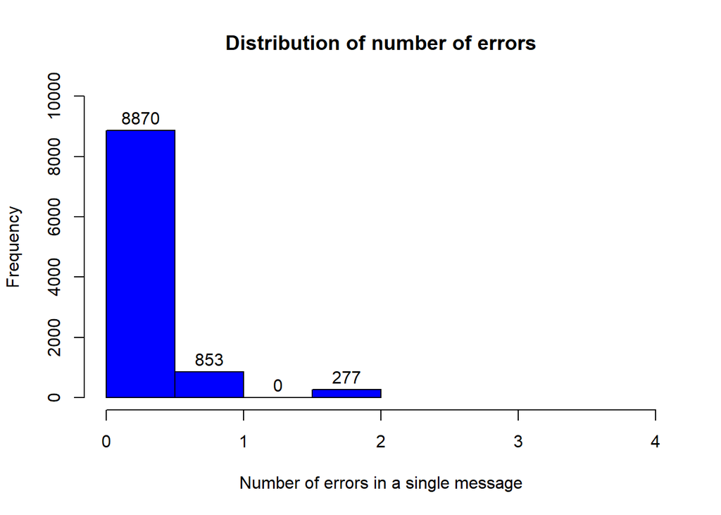

```r
test <- count_k(messages, decoded)
temp <- test[,5]
h <- hist(temp,
     main = "Distribution of number of errors",
     xlab = 'Number of errors in a single message',
     xlim=c(0,4),
     ylim = c(0, 10000),
     col = 'blue',
     border = 'black',
     breaks = 6)
text(h$mids,h$counts,labels=h$counts, adj=c(0.5, -0.5))
```

At the histogram we can see that we do not have decoded words with more than two errors because of small value of measurement error, which is equal to 10%. the random variable that counts the number of wrong bits in a decoded message isn’t one of the known distributions, but looks like binomial one.

**Do not forget to include several sentences summarizing your work and the conclusions you have made!**

### Task 2(Sofiia Folvarochna)

#### In this task, we discuss a real-life process that is well modeled by a Poisson distribution. As you remember, a Poisson random variable describes occurrences of rare events, i.e., counts the number of successes in a large number of independent random experiments. One of the typical examples is the **radioactive decay** process.

#### Consider a sample of radioactive element of mass $m$, which has a big *half-life period* $T$; it is vitally important to know the probability that during a one second period, the number of nuclei decays will not exceed some critical level $k$. This probability can easily be estimated using the fact that, given the *activity* ${\lambda}$ of the element (i.e., the probability that exactly one nucleus decays in one second) and the number $N$ of atoms in the sample, the random number of decays within a second is well modeled by Poisson distribution with parameter $\mu:=N\lambda$. Next, for the sample of mass $m$, the number of atoms is $N = \frac{m}{M} N_A$, where $N_A = 6 \times 10^{23}$ is the Avogadro constant, and $M$ is the molar (atomic) mass of the element. The activity of the element, $\lambda$, is $\log(2)/T$, where $T$ is measured in seconds.

#### Assume that a medical laboratory receives $n$ samples of radioactive element ${{}^{137}}\mathtt{Cs}$ (used in radiotherapy) with half-life period $T = 30.1$ years and mass $m = \mathtt{team\, id \,number} \times 10^{-6}$ g each. Denote by $X_1,X_2,\dots,X_n$ the **i.i.d. r.v.**’s counting the number of decays in sample $i$ in one second.

1. Specify the parameter of the Poisson distribution of $X_i$ (you’ll need the atomic mass of *Cesium-137*)
2. Show that the distribution of the sample means of $X_1,\dots,X_n$ gets very close to a normal one as $n$ becomes large and identify that normal distribution. To this end,
   - simulate the realization $x_1,x_2,\dots,x_n$ of the $X_i$ and calculate the sample mean $s=\overline{\mathbf{x}}$;
   - repeat this $K$ times to get the sample $\mathbf{s}=(s_1,\dots,s_K)$ of means and form the empirical cumulative distribution function $\hat F_{\mathbf{s}}$ of $\mathbf{s}$;
   - identify $\mu$ and $\sigma^2$ such that the $F$ of $\mathscr{N}(\mu,\sigma^2)$ is close to the $\hat F_{\mathbf{s}}$ and plot both **c.d.f.**’s on one graph to visualize their proximity (use the proper scales!);
   - calculate the maximal difference between the two ’s;
   - consider cases $n = 5$, $n = 10$, $n=50$ and comment on the results.
3. Calculate the largest possible value of $n$, for which the total number of decays in one second is less than $8 \times 10^8$ with probability at least $0.95$. To this end,
   - obtain the theoretical bound on $n$ using Markov inequality, Chernoff bound and Central Limit Theorem, and compare the results;
   - simulate the realization $x_1,x_2,\dots,x_n$ of the $X_i$ and calculate the sum $s=x_1 + \cdots +x_n$;
   - repeat this $K$ times to get the sample $\mathbf{s}=(s_1,\dots,s_K)$ of sums;
   - calculate the number of elements of the sample which are less than critical value ($8 \times 10^8$) and calculate the empirical probability; comment whether it is close to the desired level $0.95$

```r
lambda <- log(2)/(9.49864255*10^8)
N <- (10**18 * 6)/136.9
K <- 1000
mu <- N * lambda
i <- 1
#calculate all values of n when empirical probability is greater than 0.95
while(TRUE){
  sum_values <- colSums(matrix(rpois(i*K, lambda = mu), nrow=i))
  if ((sum(sum_values < 8*10**8)/K)<0.95){
    break
  }
  i<-i+1
}
i-1
```

```
## [1] 25
```

First, we have found this number experimentally and saw that for all $n \le 25$ the empirical probability is 1 and 0 otherwise, because all 1000 sums are less than $8 \cdot 10^8$ and when $n \ge 26$ all elements of sample are bigger than $8 \cdot 10^8$. We can prove it using Central Limit Theorem:

$$P(M_n -m \mu \le 8 \cdot 10^8)$$

$$P(\frac{S_n - \mu \cdot n}{\sigma \cdot \sqrt{n}} \le \frac{8 \cdot 10^8
- \mu \cdot n}{\sigma \cdot \sqrt{n}})$$

$$\Phi(\frac{8 \cdot 10^8 - \mu \cdot n}{\sigma \cdot \sqrt{n}}) \ge 0.95$$

$$\frac{8 \cdot 10^8 - 31982449 \cdot n}{5655.303 \cdot \sqrt{n}} \ge 1.65$$

$$n \le 25$$

As we can see our results are similar to which we found using CLT. To obtain elements which are smaller than $8 \cdot 10^8$ n should be smaller than or equal to 25.

Now we can compare our results to ones which we can obtain using Markov inequality:

$$P(S_n \le 8 \cdot 10^8) = 1 - P(S_n \ge 8 \cdot 10^8) \ge 0.95$$

$$-P(S_n \ge 8 \cdot 10^8) \ge -0.05$$

$$P(S_n \ge 8 \cdot 10^8) \le 0.05$$

$$\frac{n \cdot 31982449}{8 \cdot 10^8} \le 0.05$$

$$n \le 1$$

That means that for n less or equal to 1 all elements of sample are smaller than $8 \cdot 10^8$.

```r
# calculating lambda, mu and finding sample means for n = 5, n = 10 and n = 50
lambda <- log(2)/949864255.2
N <- (10**18 * 6)/136.9
mu <- N * lambda
K <- 1e3
n1 <- 5
n2 <- 10
n3 <- 50
sample_means1 <- colMeans(matrix(rpois(n1*K, lambda = mu), nrow=n1))
sample_means2 <- colMeans(matrix(rpois(n2*K, lambda = mu), nrow=n2))
sample_means3 <- colMeans(matrix(rpois(n3*K, lambda = mu), nrow=n3))
```

#### Next, calculate the parameters of the standard normal approximation

```r
# calculating mean and standart deviation of sample means
mu1 <- mean(sample_means1)
sigma1 <- sd(sample_means1)
mu2 <- mean(sample_means2)
sigma2 <- sd(sample_means2)
mu3 <- mean(sample_means3)
sigma3 <- sd(sample_means3)
```

#### We can now plot e.c.d.f. and c.d.f.

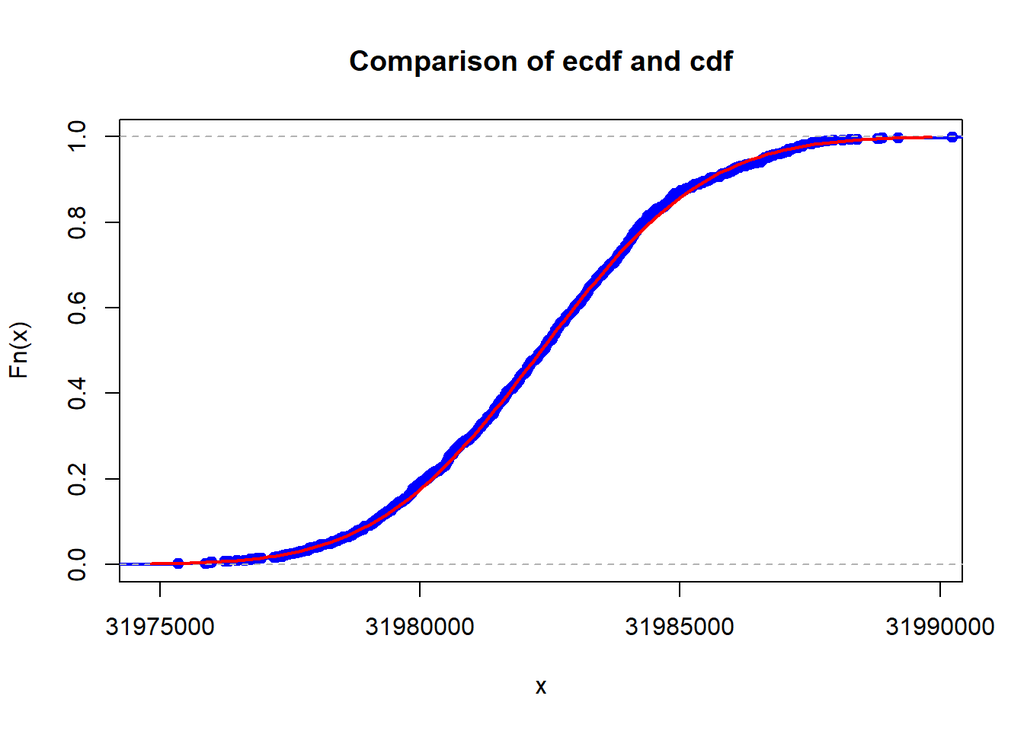

```r
xlims_1 <- c(mu1-3*sigma1,mu1+3*sigma1)
Fs_1 <- ecdf(sample_means1)
plot(Fs_1,
     xlim = xlims_1,
     ylim = c(0,1),
     col = "blue",
     lwd = 2,
     main = "Comparison of ecdf and cdf")
curve(pnorm(x, mean = mu1, sd = sigma1), col = "red", lwd = 2, add = TRUE)
```

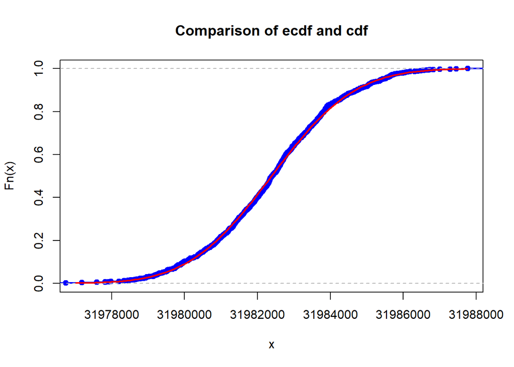

```r
xlims_2 <- c(mu2-3*sigma2,mu2+3*sigma2)
Fs_2 <- ecdf(sample_means2)
plot(Fs_2,
     xlim = xlims_2,
     ylim = c(0,1),
     col = "blue",
     lwd = 2,
     main = "Comparison of ecdf and cdf")
curve(pnorm(x, mean = mu2, sd = sigma2), col = "red", lwd = 2, add = TRUE)
```

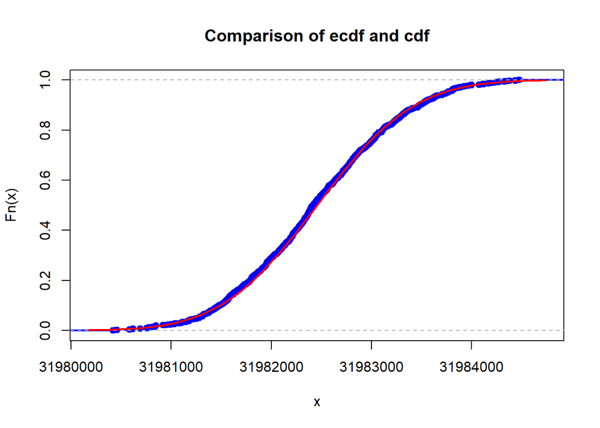

```r
xlims_3 <- c(mu3-3*sigma3,mu3+3*sigma3)
Fs_3 <- ecdf(sample_means3)
plot(Fs_3,
     xlim = xlims_3,
     ylim = c(0,1),
     col = "blue",
     lwd = 2,
     main = "Comparison of ecdf and cdf")
curve(pnorm(x, mean = mu3, sd = sigma3), col = "red", lwd = 2, add = TRUE)
```

**Next, proceed with all the remaining steps**

```r
# calculatng the maximum difference between two c.d.f.'s
x <- seq(min(sample_means1),max(sample_means1), by = .01)
max(abs(Fs_1(x)-pnorm(x,mean = mean(sample_means1), sd = sd(sample_means1))))
```

```
## [1] 0.01890788
```

```r
x <- seq(min(sample_means2),max(sample_means2), by = .01)
max(abs(Fs_2(x)-pnorm(x,mean = mean(sample_means2), sd = sd(sample_means2))))
```

```
## [1] 0.02204531
```

```r
x <- seq(min(sample_means1),max(sample_means1), by = .01)
max(abs(Fs_3(x)-pnorm(x,mean = mean(sample_means3), sd = sd(sample_means3))))
```

```
## [1] 0.02200594
```

```r
lambda <- log(2)/949864255.2
N <- (10**18 * 6)/136.9
K <- 1000
n <- 5
mu <- N * lambda
sum_values <- colSums(matrix(rpois(n*K, lambda = mu), nrow=n))
sum(sum_values < 8*10**8)
```

```
## [1] 1000
```

**Do not forget to include several sentences summarizing your work and the conclusions you have made!**

### Task 3(Andrea Kozlovskyy)

#### In this task, we use the Central Limit Theorem approximation for continuous random variables.

#### One of the devices to measure radioactivity level at a given location is the Geiger counter. When the radioactive level is almost constant, the time between two consecutive clicks of the Geiger counter is an exponentially distributed random variable with parameter $\nu_1 = \mathtt{team\,id\,number} + 10$. Denote by $X_k$ the random time between the $(k-1)^{\mathrm{st}}$ and $k^{\mathrm{th}}$ click of the counter.

1. Show that the distribution of the sample means of $X_1, X_2,\dots,X_n$ gets very close to a normal one (which one?) as $n$ becomes large. To this end,
   - simulate the realizations $x_1,x_2,\dots,x_n$ of the $X_i$ and calculate the sample mean $s=\overline{\mathbf{x}}$;
   - repeat this $K$ times to get the sample $\mathbf{s}=(s_1,\dots,s_K)$ of means and then the function $F_{\mathbf{s}}$ of $\mathbf{s}$;
   - identify $\mu$ and $\sigma^2$ such that the of $\mathscr{N}(\mu,\sigma^2)$ is close to the $F_{\mathbf{s}}$ of and plot both ’s on one graph to visualize their proximity;
   - calculate the maximal difference between the two ’s;
   - consider cases $n = 5$, $n = 10$, $n=50$ and comment on the results.
2. The place can be considered safe when the number of clicks in one minute does not exceed $100$. It is known that the parameter $\nu$ of the resulting exponential distribution is proportional to the number $N$ of the radioactive samples, i.e., $\nu = \nu_1*N$, where $\nu_1$ is the parameter for one sample. Determine the maximal number of radioactive samples that can be stored in that place so that, with probability $0.95$, the place is identified as safe. To do this,
   - express the event of interest in terms of the $S:= X_1 + \cdots + X_{100}$;
   - obtain the theoretical bounds on $N$ using the Markov inequality, Chernoff bound and Central Limit Theorem and compare the results;
   - with the predicted $N$ and thus $\nu$, simulate the realization $x_1,x_2,\dots,x_{100}$ of the $X_i$ and of the sum $S = X_1 + \cdots + X_{100}$;
   - repeat this $K$ times to get the sample $\mathbf{s}=(s_1,\dots,s_K)$ of total times until the $100^{\mathrm{th}}$ click;
   - estimate the probability that the location is identified as safe and compare to the desired level $0.95$

#### First, generate samples an sample means:

```r
nu1 <- 20  # change this!
K <- 1e3
n1 <- 5
n2 <- 10
n3 <- 50
sample_means1 <- colMeans(matrix(rexp(n1*K, rate = nu1), nrow=n1))
sample_means2 <- colMeans(matrix(rexp(n2*K, rate = nu1), nrow=n2))
sample_means3 <- colMeans(matrix(rexp(n3*K, rate = nu1), nrow=n3))
```

#### Next, calculate the parameters of the standard normal approximation

```r
mu1 <- mean(sample_means1)# change this!
sigma1 <- sd(sample_means1)
mu2 <- mean(sample_means2)# change this!
sigma2 <- sd(sample_means2)
mu3 <- mean(sample_means3)# change this!
sigma3 <- sd(sample_means3) # change this!
```

#### We can now plot e.c.d.f. and c.d.f.

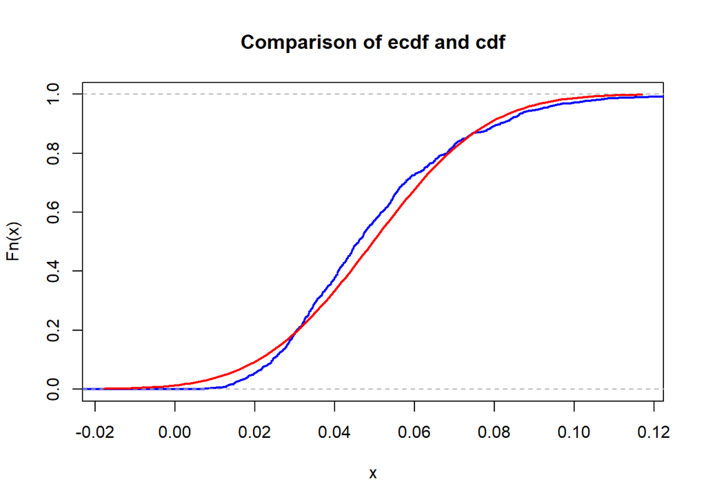

```r
xlims_1 <- c(mu1-3*sigma1,mu1+3*sigma1)
Fs_1 <- ecdf(sample_means1)
plot(Fs_1,
     xlim = xlims_1,
     col = "blue",
     lwd = 2,
     main = "Comparison of ecdf and cdf")
curve(pnorm(x, mean = mu1, sd = sigma1), col = "red", lwd = 2, add = TRUE)
```

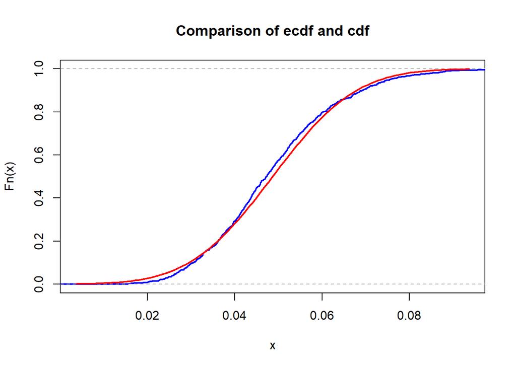

```r
xlims_2 <- c(mu2-3*sigma2,mu2+3*sigma2)
Fs_2 <- ecdf(sample_means2)
plot(Fs_2,
     xlim = xlims_2,
     col = "blue",
     lwd = 2,
     main = "Comparison of ecdf and cdf")
curve(pnorm(x, mean = mu2, sd = sigma2), col = "red", lwd = 2, add = TRUE)
```

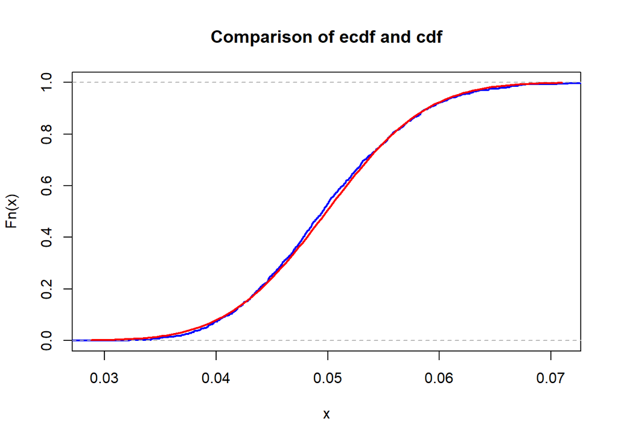

```r
xlims_3 <- c(mu3-3*sigma3,mu3+3*sigma3)
Fs_3 <- ecdf(sample_means3)
plot(Fs_3,
     xlim = xlims_3,
     col = "blue",
     lwd = 2,
     main = "Comparison of ecdf and cdf")
curve(pnorm(x, mean = mu3, sd = sigma3), col = "red", lwd = 2, add = TRUE)
```

**Considering cases n = 5, n = 10, n = 50. Here we can see that as n becomes larger the difference between c.d.f and e.c.d.f. becomes smaller. From the plots we can see that the e.c.d.f. becomes more and more similar to the c.d.f.**

```r
x <- seq(min(sample_means1),max(sample_means1), by = .01)
max(abs(Fs_1(x)-pnorm(x,mean = mean(sample_means1), sd = sd(sample_means1))))
```

```
## [1] 0.06231562
```

```r
x <- seq(min(sample_means2),max(sample_means2), by = .01)
max(abs(Fs_2(x)-pnorm(x,mean = mean(sample_means2), sd = sd(sample_means2))))
```

```
## [1] 0.04402133
```

```r
x <- seq(min(sample_means1),max(sample_means1), by = .01)
max(abs(Fs_3(x)-pnorm(x,mean = mean(sample_means3), sd = sd(sample_means3))))
```

```
## [1] 0.009001763
```

**Next, proceed with all the remaining steps**

**Estimate the probability that the location is identified as safe and compare to the desired level** $0.95$

Let’s find theoretical bounds of N using Markov inequality:

$$P(S_{100} \ge a) \le \frac{E(S_{100})}{a}$$

$$P(S_{100} \ge 1) \le E(S_{100}) = \frac{100}{\lambda \cdot N}$$

$$\frac{100}{\lambda \cdot N} \ge 0.95$$

$$N \le \frac{100}{20 \cdot 0.95}$$

So the location can be identified as safe if number of samples will be less or equal to 5.

Now let’s calculate bounds using Chebyshev inequality and compare them to already obtained results:

$$P(S_{100} - \mu \ge c) \le \frac{\sigma^2}{c^2 + \sigma^2}$$

$$P(S_{100} - \frac{100}{\lambda \cdot N} \ge 1 - \frac{100}{\lambda \cdot
N}) \le \frac{1}{\lambda^2 \cdot ((1 - {\frac{100}{\lambda \cdot N}})^2
+ \frac{1}{\lambda^2})}$$

And, since $\lambda$ = 20:

$$P(S_{100} - \frac{5}{N} \ge 1 - \frac{5}{N}) \le \frac{1}{400 \cdot ((1
- {\frac{5}{N}})^2 + \frac{1}{400})} = \frac{1}{400 \cdot (1 -
{\frac{5}{N}})^2 + 1}$$

$$\frac{1}{400 \cdot (1 - {\frac{5}{N}})^2 + 1} \ge 0.95$$

$$400 \cdot (1 - {\frac{5}{N}})^2 + 1 \le \frac{1}{0.95}$$

$$1 - {\frac{5}{N}} \le 0.0115$$

$$\frac{5}{N} \ge 0.9885$$

And we can see that the results are the same.

Finally, let’s obtain bounds using CLT:

$$P(S_{100} \ge 1) = 1 - P(S_{100} \le 1) =$$

$$= 1 - P(\frac{S_{100} - n \cdot \mu}{\sqrt{n} \cdot \sigma} \le \frac{1
- n \cdot \mu}{\sqrt{n} \cdot \sigma}) =$$

$$= 1 - P(\frac{S_{100} - 100 \cdot \frac{1}{20 \cdot N}}{10 \cdot
\frac{1}{20 \cdot N}} \le \frac{1 - 100 \cdot \frac{1}{20 \cdot N}}{10
\cdot \frac{1}{20 \cdot N}}) =$$

$$= 1 - \Phi(\frac{1 - \frac{5}{N}}{\frac{1}{2 \cdot N}}) \ge 0.95$$

$$\Phi(2 \cdot N - 10) \le 0.05$$

$$2 \cdot N - 10 \le -1.64$$

$$2 \cdot N \le 8.36$$

$$N < 5$$

As we can see the result are similar.

**Task 3.2**

```r
num = 100
sample_means4 <- colMeans(matrix(rexp(num*K, rate = nu1), nrow=num))
S = sum(sample_means4[1:100])
```

**Markov bounds**

```r
time = 1
prob = 0.95

Markov_num = num / (prob * nu1 * time)

Markov_num #Upper bound
```

```
## [1] 5.263158
```

**Chebyshev bound**

```r
Chebyshev_num = (num * prob + sqrt(num * prob - prob * prob)) / (nu1 * time * prob)
Chebyshev_num #Upper bound
```

```
## [1] 5.510547
```

**Central Limit Theorem** We take our number(CLT_num) to be minimum in this case 1. Then we calculate normal distribution and check wether it is less then the probability of 0.05, as 1 - ND needs to be greater than 0.95.

```r
CLT_num = 1
while(TRUE){
  flag = pnorm((time - (num / (nu1 * CLT_num))) / (sqrt(num) / (nu1 * CLT_num)))
  if (flag < 0.05){
    CLT_num = CLT_num + 1
  }
  else{
    break
  }
}
CLT_num = CLT_num - 1
CLT_num
```

```
## [1] 4
```

**Simulation of S**

```r
new_S = sum(rexp(100, rate = CLT_num * nu1))
new_S
```

```
## [1] 1.306685
```

**Repeat k-times**

```r
sums = colSums(matrix(rexp(100*K, rate = CLT_num * nu1), nrow = 100))
```

**Estimation of probability that location is safe(Greater than 0.95)**

```r
mean(sums >= 1)
```

```
## [1] 0.989
```

**Do not forget to include several sentences summarizing your work and the conclusions you have made!**

Completing this task we used CLT approximation for continuous r.v.

In this task we could clearly see that with Central Limit Theory we can derive much accurate bound than in Chebyshev or Markov bounds. Four samples proved to be a maximum number for safe storage. Assuming that we limit sum of time between ticks by 1 minute rather than 60 seconds.

We also saw to which real-life processes exponential distribution is implied. Also we saw how connected values of n and difference between e.c.d.f. and c.d.f. We discovered that theoretical bounds using CLT are to those which we found experimentally.

### General summary and conclusions

Completing this lab assignment, we learned more about CLT, distributions of r.v., Markov inequality and Chebyshev inequality. The most difficult task which we failed to complete was Chernoff bound. We learned more about e.c.d.f. because we did not have this task on seminars, and here we had the possibility to learn more about that. We experimentally discovered that data which we get are similar to theoretical one.